# Pokémon Power Creep Analysis

## 6.3 LASSO Regression (α = 1)

```r
# FULL DATA
set.seed(42)
cv_lasso <- cv.glmnet(X, y, alpha = 1, nfolds = 10)
cat("--- LASSO Regression (Full Data) ---\n")
```

```
## --- LASSO Regression (Full Data) ---
```

```r
cat("Optimal lambda (min):", cv_lasso$lambda.min, "\n")
```

```
## Optimal lambda (min): 0.4194251
```

```r
lasso_model <- glmnet(X, y, alpha = 1, lambda = cv_lasso$lambda.min)
cat("\nLASSO coefficients (non-zero only = selected features):\n")
```

```
##
## LASSO coefficients (non-zero only = selected features):
```

```r
lasso_coef <- coef(lasso_model)
print(lasso_coef[lasso_coef[,1] != 0, ])
```

```
##     (Intercept)            gen2            gen5            gen6            gen7
##    45.450688233    -4.885199249     4.026419773    -1.332173850     2.665500079
##            gen8            gen9              hp         defense       sp_attack
##     2.449161481    -0.625640684     0.253480501     0.326105923    -0.009111411
##      sp_defense           speed        height_m       weight_kg    capture_rate
##    -0.232262765     0.232075236     0.733025351     0.019961321    -0.093500661
##      evo_length rarityLegendary  rarityMythical
##    -0.567411341     2.617685581     1.326477372
```

```r
n_selected <- sum(lasso_coef[,1] != 0) - 1
cat("\nNumber of features selected by LASSO:", n_selected, "\n")
```

```
##
## Number of features selected by LASSO: 17
```

```r
# OUTLIER-FREE DATA
set.seed(42)
cv_lasso_clean <- cv.glmnet(X_clean, y_clean, alpha = 1, nfolds = 10)
cat("\n--- LASSO Regression (Outlier-Free) ---\n")
```

```
##
## --- LASSO Regression (Outlier-Free) ---
```

```r
cat("Optimal lambda (min):", cv_lasso_clean$lambda.min, "\n")
```

```
## Optimal lambda (min): 0.3336531
```

```r
lasso_model_clean <- glmnet(X_clean, y_clean, alpha = 1, lambda = cv_lasso_clean$lambda.min)
cat("\nLASSO coefficients (non-zero only = selected features):\n")
```

```
##
## LASSO coefficients (non-zero only = selected features):
```

```r
lasso_coef_clean <- coef(lasso_model_clean)
print(lasso_coef_clean[lasso_coef_clean[,1] != 0, ])
```

```
##        (Intercept)               gen2               gen5               gen6
##        46.56257445        -5.86113664         4.78264438        -1.40856982
##               gen7               gen8               gen9                 hp
##         2.72397633         2.67921657        -0.61185081         0.20171376
##            defense          sp_attack         sp_defense              speed
##         0.32339120        -0.04483748        -0.22998380         0.23149089
##           height_m          weight_kg       capture_rate         evo_length
##         2.90698436         0.04067127        -0.08978435        -0.31901676
## raritySubLegendary    rarityLegendary     rarityMythical
##        -0.97606651         3.41413076         2.03033747
```

```r
n_selected_clean <- sum(lasso_coef_clean[,1] != 0) - 1
cat("\nNumber of features selected by LASSO:", n_selected_clean, "\n")
```

```
##
## Number of features selected by LASSO: 18
```

```r
# Compare generation coefficients
cat("\n--- LASSO Generation Coefficients Comparison ---\n")
```

```
##
## --- LASSO Generation Coefficients Comparison ---
```

```r
# Get all coefficient names from both models
coef_full_mat <- as.matrix(lasso_coef)
coef_clean_mat <- as.matrix(lasso_coef_clean)

# Find generation-related coefficients (matching "gen" in name)
gen_idx_full <- grep("^gen", rownames(coef_full_mat))
gen_idx_clean <- grep("^gen", rownames(coef_clean_mat))

# Get the generation names that exist in both
gen_names_full <- rownames(coef_full_mat)[gen_idx_full]
gen_names_clean <- rownames(coef_clean_mat)[gen_idx_clean]
all_gen_names <- union(gen_names_full, gen_names_clean)

# Safely extract coefficients (0 if not present)
get_coef <- function(coef_mat, name) {
  if (name %in% rownames(coef_mat)) coef_mat[name, 1] else 0
}

lasso_gen_full <- sapply(all_gen_names, function(n) get_coef(coef_full_mat, n))
lasso_gen_clean <- sapply(all_gen_names, function(n) get_coef(coef_clean_mat, n))

lasso_comparison <- data.frame(
  Gen = all_gen_names,
  Full = round(lasso_gen_full, 3),
  Clean = round(lasso_gen_clean, 3),
  Both_Selected = ifelse(lasso_gen_full != 0 & lasso_gen_clean != 0, "Yes",
                         ifelse(lasso_gen_full != 0 | lasso_gen_clean != 0, "One only", "Neither"))
)
rownames(lasso_comparison) <- NULL
print(lasso_comparison)
```

```
##    Gen   Full  Clean Both_Selected
## 1 gen1  0.000  0.000       Neither
## 2 gen2 -4.885 -5.861           Yes
## 3 gen3  0.000  0.000       Neither
## 4 gen4  0.000  0.000       Neither
## 5 gen5  4.026  4.783           Yes
## 6 gen6 -1.332 -1.409           Yes
## 7 gen7  2.666  2.724           Yes
## 8 gen8  2.449  2.679           Yes
## 9 gen9 -0.626 -0.612           Yes
```

**Findings:** Compare which generation dummies LASSO selects in full vs outlier-free data. If the same generations are retained, the feature selection is robust to outliers.

## 6.4 Elastic Net (α = 0.5)

```r
set.seed(42)
cv_enet <- cv.glmnet(X, y, alpha = 0.5, nfolds = 10)
cat("--- Elastic Net Regression ---\n")
```

```
## --- Elastic Net Regression ---
```

```r
cat("Optimal lambda:", cv_enet$lambda.min, "\n")
```

```
## Optimal lambda: 0.7643291
```

```r
enet_model <- glmnet(X, y, alpha = 0.5, lambda = cv_enet$lambda.min)
cat("\nElastic Net coefficients:\n")
```

```
##
## Elastic Net coefficients:
```

```r
print(coef(enet_model))
```

```
## 23 x 1 sparse Matrix of class "dgCMatrix"
##                             s0
## (Intercept)        46.11496385
## gen1                .
## gen2               -4.98794598
## gen3                .
## gen4                .
## gen5                4.09313995
## gen6               -1.46180573
## gen7                2.72663877
## gen8                2.54898253
## gen9               -0.68164314
## hp                  0.25001879
## defense             0.31953527
## sp_attack          -0.01167045
## sp_defense         -0.22615566
## speed               0.22917297
## height_m            0.80771043
## weight_kg           0.02015960
## capture_rate       -0.09366530
## num_abilities       .
## evo_length         -0.59784151
## raritySubLegendary  .
## rarityLegendary     2.87405968
## rarityMythical      1.74238591
```

## 6.5 Regularization Paths

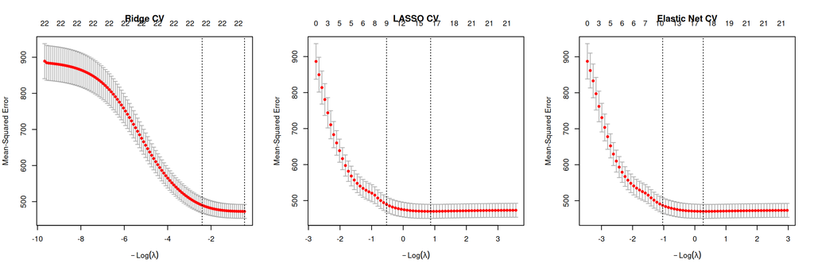

```r
par(mfrow = c(1, 3))
plot(cv_ridge, main = "Ridge CV")
plot(cv_lasso, main = "LASSO CV")
plot(cv_enet, main = "Elastic Net CV")
```

# 7. Generalized Linear Models (GLMs)

## 7.1 Gaussian GLM

Equivalent to OLS for continuous target.

```r
# FULL DATA
glm_gaussian <- glm(attack ~ gen + hp + defense + sp_attack + sp_defense + speed +
                      rarity + weight_kg + height_m,
                    data = pokemon, family = gaussian(link = "identity"))
cat("--- GLM: Gaussian (Attack ~ predictors) - FULL DATA ---\n")
```

```
## --- GLM: Gaussian (Attack ~ predictors) - FULL DATA ---
```

```r
summary(glm_gaussian)
```

```
##
## Call:
## glm(formula = attack ~ gen + hp + defense + sp_attack + sp_defense +
##     speed + rarity + weight_kg + height_m, family = gaussian(link = "identity"),
##     data = pokemon)
##
## Coefficients:
##                     Estimate Std. Error t value Pr(>|t|)
## (Intercept)        11.683300   3.433725   3.403 0.000694 ***
## gen2               -3.743217   2.842142  -1.317 0.188125
## gen3                1.345040   2.602014   0.517 0.605324
## gen4                2.073039   2.792903   0.742 0.458108
## gen5                5.598478   2.512160   2.229 0.026064 *
## gen6               -2.302142   3.154291  -0.730 0.465655
## gen7                6.254605   3.028615   2.065 0.039163 *
## gen8                4.978059   2.874713   1.732 0.083639 .
## gen9               -0.250319   2.710432  -0.092 0.926435
## hp                  0.344979   0.032213  10.709  < 2e-16 ***
## defense             0.426009   0.029706  14.341  < 2e-16 ***
## sp_attack           0.013396   0.030079   0.445 0.656155
## sp_defense         -0.229414   0.034085  -6.731 2.83e-11 ***
## speed               0.327982   0.027476  11.937  < 2e-16 ***
## raritySubLegendary  0.759752   3.532901   0.215 0.829772
## rarityLegendary     2.997709   5.354537   0.560 0.575710
## rarityMythical      5.822917   5.189583   1.122 0.262114
## weight_kg           0.019503   0.008345   2.337 0.019629 *
## height_m            0.547211   0.767266   0.713 0.475890
## ---
## Signif. codes:  0 '***' 0.001 '**' 0.01 '*' 0.05 '.' 0.1 ' ' 1
##
## (Dispersion parameter for gaussian family taken to be 477.3262)
##
##     Null deviance: 909432  on 1023  degrees of freedom
## Residual deviance: 479713  on 1005  degrees of freedom
## AIC: 9243
##
## Number of Fisher Scoring iterations: 2
```

```r
# OUTLIER-FREE DATA
glm_gaussian_clean <- glm(attack ~ gen + hp + defense + sp_attack + sp_defense + speed +
                            rarity + weight_kg + height_m,
                          data = pokemon_clean, family = gaussian(link = "identity"))
cat("\n--- GLM: Gaussian (Attack ~ predictors) - OUTLIER-FREE ---\n")
```

```
##
## --- GLM: Gaussian (Attack ~ predictors) - OUTLIER-FREE ---
```

```r
summary(glm_gaussian_clean)
```

```
##
## Call:
## glm(formula = attack ~ gen + hp + defense + sp_attack + sp_defense +
##     speed + rarity + weight_kg + height_m, family = gaussian(link = "identity"),
##     data = pokemon_clean)
##
## Coefficients:
##                     Estimate Std. Error t value Pr(>|t|)
## (Intercept)        15.612520   3.409562   4.579 5.29e-06 ***
## gen2               -4.798437   2.830844  -1.695 0.090392 .
## gen3                0.001855   2.586741   0.001 0.999428
## gen4                2.227820   2.765386   0.806 0.420669
## gen5                5.774811   2.460281   2.347 0.019118 *
## gen6               -2.470301   3.137870  -0.787 0.431329
## gen7                6.115343   3.035416   2.015 0.044220 *
## gen8                4.718636   2.846378   1.658 0.097693 .
## gen9               -0.750018   2.663493  -0.282 0.778318
## hp                  0.281617   0.033827   8.325 2.90e-16 ***
## defense             0.411099   0.030839  13.331  < 2e-16 ***
## sp_attack          -0.014022   0.030096  -0.466 0.641399
## sp_defense         -0.227977   0.034658  -6.578 7.86e-11 ***
## speed               0.317522   0.027150  11.695  < 2e-16 ***
## raritySubLegendary -1.882402   3.760020  -0.501 0.616743
## rarityLegendary     3.364834   7.426014   0.453 0.650569
## rarityMythical      4.961461   5.568728   0.891 0.373181
## weight_kg           0.041218   0.010982   3.753 0.000185 ***
## height_m            3.346436   1.029654   3.250 0.001194 **
## ---
## Signif. codes:  0 '***' 0.001 '**' 0.01 '*' 0.05 '.' 0.1 ' ' 1
##
## (Dispersion parameter for gaussian family taken to be 443.3734)
##
##     Null deviance: 814519  on 971  degrees of freedom
## Residual deviance: 422535  on 953  degrees of freedom
## AIC: 8703
##
## Number of Fisher Scoring iterations: 2
```

```r
# NORMAL RARITY ONLY (no rarity predictor)
glm_gaussian_normal <- glm(attack ~ gen + hp + defense + sp_attack + sp_defense + speed +
                             weight_kg + height_m,
                           data = pokemon_normal, family = gaussian(link = "identity"))
cat("\n--- GLM: Gaussian (Attack ~ predictors) - NORMAL ONLY ---\n")
```

```
##
## --- GLM: Gaussian (Attack ~ predictors) - NORMAL ONLY ---
```

```r
summary(glm_gaussian_normal)
```

```
##
## Call:
## glm(formula = attack ~ gen + hp + defense + sp_attack + sp_defense +
##     speed + weight_kg + height_m, family = gaussian(link = "identity"),
##     data = pokemon_normal)
##
## Coefficients:
##             Estimate Std. Error t value Pr(>|t|)
## (Intercept) 12.80654    3.50501   3.654 0.000273 ***
## gen2        -4.21952    2.88206  -1.464 0.143519
## gen3         0.68783    2.64579   0.260 0.794944
## gen4         2.25955    2.88390   0.784 0.433532
## gen5         5.03931    2.55886   1.969 0.049213 *
## gen6        -4.01832    3.22183  -1.247 0.212636
## gen7         6.45099    3.30874   1.950 0.051518 .
## gen8         4.26060    2.91567   1.461 0.144282
## gen9        -1.01035    2.72723  -0.370 0.711120
## hp           0.35915    0.03447  10.419  < 2e-16 ***
## defense      0.40870    0.03124  13.082  < 2e-16 ***
## sp_attack   -0.02391    0.03145  -0.760 0.447401
## sp_defense  -0.19568    0.03676  -5.323 1.28e-07 ***
## speed        0.32405    0.02845  11.392  < 2e-16 ***
## weight_kg    0.04270    0.01089   3.922 9.44e-05 ***
## height_m    -0.52812    0.83230  -0.635 0.525892
## ---
## Signif. codes:  0 '***' 0.001 '**' 0.01 '*' 0.05 '.' 0.1 ' ' 1
##
## (Dispersion parameter for gaussian family taken to be 466.5088)
##
##     Null deviance: 770999  on 933  degrees of freedom
## Residual deviance: 428255  on 918  degrees of freedom
## AIC: 8408.1
##
## Number of Fisher Scoring iterations: 2
```

```r
# AIC comparison
cat("\n--- AIC Comparison ---\n")
```

```
##
## --- AIC Comparison ---
```

```r
cat("Full data AIC:", round(AIC(glm_gaussian), 1), "\n")
```

```
## Full data AIC: 9243
```

```r
cat("Outlier-free AIC:", round(AIC(glm_gaussian_clean), 1), "\n")
```

```
## Outlier-free AIC: 8703
```

```r
cat("Normal-only AIC:", round(AIC(glm_gaussian_normal), 1), "(not directly comparable - different N)\n")
```

```
## Normal-only AIC: 8408.1 (not directly comparable - different N)
```

**Findings:** Gaussian GLM shows which generations are significant. The Normal-only model tests power creep without legendary influence — significant generation effects here confirm the trend exists among regular Pokémon.

## 7.2 Gamma GLM

For positive continuous data, handles heteroscedasticity.

```r
glm_gamma <- glm(attack ~ gen + hp + defense + sp_attack + sp_defense + speed +
                   rarity + weight_kg,
                 data = pokemon, family = Gamma(link = "log"))
cat("--- GLM: Gamma with log link ---\n")
```

```
## --- GLM: Gamma with log link ---
```

```r
summary(glm_gamma)
```

```
##
## Call:
## glm(formula = attack ~ gen + hp + defense + sp_attack + sp_defense +
##     speed + rarity + weight_kg, family = Gamma(link = "log"),
##     data = pokemon)
##
## Coefficients:
##                      Estimate Std. Error t value Pr(>|t|)
## (Intercept)         3.3508069  0.0470503  71.218  < 2e-16 ***
## gen2               -0.0686034  0.0391411  -1.753   0.0800 .
## gen3                0.0046996  0.0358333   0.131   0.8957
## gen4                0.0029627  0.0383258   0.077   0.9384
## gen5                0.0583306  0.0345059   1.690   0.0913 .
## gen6               -0.0479452  0.0433872  -1.105   0.2694
## gen7                0.0637041  0.0416535   1.529   0.1265
## gen8                0.0330994  0.0395921   0.836   0.4033
## gen9               -0.0306818  0.0372343  -0.824   0.4101
## hp                  0.0051714  0.0004342  11.909  < 2e-16 ***
## defense             0.0059975  0.0004076  14.715  < 2e-16 ***
## sp_attack           0.0007267  0.0004097   1.774   0.0764 .
## sp_defense         -0.0028464  0.0004692  -6.067 1.84e-09 ***
## speed               0.0044856  0.0003746  11.975  < 2e-16 ***
## raritySubLegendary -0.0401065  0.0485597  -0.826   0.4090
## rarityLegendary    -0.0801991  0.0737140  -1.088   0.2769
## rarityMythical      0.0191888  0.0711170   0.270   0.7874
## weight_kg           0.0001705  0.0001015   1.680   0.0934 .
## ---
## Signif. codes:  0 '***' 0.001 '**' 0.01 '*' 0.05 '.' 0.1 ' ' 1
##
## (Dispersion parameter for Gamma family taken to be 0.09054212)
##
##     Null deviance: 177.27  on 1023  degrees of freedom
## Residual deviance: 102.34  on 1006  degrees of freedom
## AIC: 9335.1
##
## Number of Fisher Scoring iterations: 7
```

## 7.3 Poisson GLM for Count Data

Using `num_abilities` as the response variable.

```r
glm_poisson <- glm(num_abilities ~ gen + rarity + hp + attack + defense + speed,
                   data = pokemon, family = poisson(link = "log"))
cat("--- GLM: Poisson (Number of Abilities) ---\n")
```

```
## --- GLM: Poisson (Number of Abilities) ---
```

```r
summary(glm_poisson)
```

```
##
## Call:
## glm(formula = num_abilities ~ gen + rarity + hp + attack + defense +
##     speed, family = poisson(link = "log"), data = pokemon)
##
## Coefficients:
##                      Estimate Std. Error z value Pr(>|z|)
## (Intercept)         1.0677495  0.0945811  11.289  < 2e-16 ***
## gen2               -0.0117188  0.0802294  -0.146 0.883869
## gen3               -0.1338985  0.0761204  -1.759 0.078572 .
## gen4               -0.0943193  0.0814788  -1.158 0.247030
## gen5               -0.0094737  0.0711705  -0.133 0.894105
## gen6               -0.1177946  0.0929448  -1.267 0.205026
## gen7               -0.1995297  0.0936384  -2.131 0.033101 *
## gen8               -0.0942046  0.0836789  -1.126 0.260256
## gen9               -0.2243046  0.0813021  -2.759 0.005800 **
## raritySubLegendary -0.4246852  0.1244037  -3.414 0.000641 ***
## rarityLegendary    -0.4561026  0.1863307  -2.448 0.014373 *
## rarityMythical     -0.8065132  0.2224709  -3.625 0.000289 ***
## hp                  0.0004263  0.0008726   0.489 0.625136
## attack             -0.0002525  0.0009100  -0.278 0.781394
## defense            -0.0005708  0.0008259  -0.691 0.489513
## speed              -0.0007808  0.0008054  -0.969 0.332317
## ---
## Signif. codes:  0 '***' 0.001 '**' 0.01 '*' 0.05 '.' 0.1 ' ' 1
##
## (Dispersion parameter for poisson family taken to be 1)
##
##     Null deviance: 266.53  on 1023  degrees of freedom
## Residual deviance: 201.26  on 1008  degrees of freedom
## AIC: 3015.8
##
## Number of Fisher Scoring iterations: 4
```

**Findings:** Interestingly, later generations (7, 9) have *fewer* abilities than Gen 1. Rarer Pokémon also have fewer abilities. This is the opposite of power creep for this metric — newer Pokémon are simpler in terms of ability count.

### Overdispersion Check

```r
# Check mean vs variance (Poisson assumption)
cat("\nPoisson Assumption Check (mean ≈ variance):\n")
```

```
##
## Poisson Assumption Check (mean ≈ variance):
```

```r
cat("Mean num_abilities:", mean(pokemon$num_abilities), "\n")
```

```
## Mean num_abilities: 2.37207
```

```r
cat("Variance num_abilities:", var(pokemon$num_abilities), "\n")
```

```
## Variance num_abilities: 0.5486229
```

```r
# Check for overdispersion using AER package (from SAN_assignment_GLM_2.Rmd)
cat("\n--- Dispersion Test (from AER package) ---\n")
```

```
##
## --- Dispersion Test (from AER package) ---
```

```r
disp_test <- dispersiontest(glm_poisson)
print(disp_test)
```

```
##
##  Overdispersion test
##
## data:  glm_poisson
## z = -61.739, p-value = 1
## alternative hypothesis: true dispersion is greater than 1
## sample estimates:
## dispersion
##  0.1810493
```

```r
# Manual dispersion calculation
dispersion <- sum(residuals(glm_poisson, type = "pearson")^2) / glm_poisson$df.residual
cat("\nManual Dispersion parameter:", dispersion, "\n")
```

```
##
## Manual Dispersion parameter: 0.1835941
```

```r
if (disp_test$p.value < 0.05 || dispersion > 1.5) {
  cat("WARNING: Overdispersion detected! Consider Negative Binomial or Quasi-Poisson\n")
} else {
  cat("No significant overdispersion detected.\n")
}
```

```
## No significant overdispersion detected.
```

**Findings:** Variance (0.55) is actually *less* than mean (2.37), indicating underdispersion rather than overdispersion. The Poisson model is appropriate here. This is unusual but makes sense — ability counts are constrained to a narrow range (typically 2-3).

## 7.4 Quasi-Poisson (for Overdispersion)

```r
glm_quasi <- glm(num_abilities ~ gen + rarity + hp + attack + defense + speed,
                 data = pokemon, family = quasipoisson(link = "log"))
cat("--- GLM: Quasi-Poisson (correcting for overdispersion) ---\n")
```

```
## --- GLM: Quasi-Poisson (correcting for overdispersion) ---
```

```r
summary(glm_quasi)
```

```
##
## Call:
## glm(formula = num_abilities ~ gen + rarity + hp + attack + defense +
##     speed, family = quasipoisson(link = "log"), data = pokemon)
##
## Coefficients:
##                      Estimate Std. Error t value Pr(>|t|)
## (Intercept)         1.0677495  0.0405260  26.347  < 2e-16 ***
## gen2               -0.0117188  0.0343766  -0.341  0.73325
## gen3               -0.1338985  0.0326160  -4.105 4.36e-05 ***
## gen4               -0.0943193  0.0349120  -2.702  0.00702 **
## gen5               -0.0094737  0.0304951  -0.311  0.75612
## gen6               -0.1177946  0.0398249  -2.958  0.00317 **
## gen7               -0.1995297  0.0401221  -4.973 7.74e-07 ***
## gen8               -0.0942046  0.0358547  -2.627  0.00873 **
## gen9               -0.2243046  0.0348363  -6.439 1.86e-10 ***
## raritySubLegendary -0.4246852  0.0533044  -7.967 4.37e-15 ***
## rarityLegendary    -0.4561026  0.0798388  -5.713 1.46e-08 ***
## rarityMythical     -0.8065132  0.0953241  -8.461  < 2e-16 ***
## hp                  0.0004263  0.0003739   1.140  0.25444
## attack             -0.0002525  0.0003899  -0.648  0.51736
## defense            -0.0005708  0.0003539  -1.613  0.10708
## speed              -0.0007808  0.0003451  -2.263  0.02388 *
## ---
## Signif. codes:  0 '***' 0.001 '**' 0.01 '*' 0.05 '.' 0.1 ' ' 1
##
## (Dispersion parameter for quasipoisson family taken to be 0.1835944)
##
##     Null deviance: 266.53  on 1023  degrees of freedom
## Residual deviance: 201.26  on 1008  degrees of freedom
## AIC: NA
##
## Number of Fisher Scoring iterations: 4
```

## 7.5 Negative Binomial GLM

From SAN_assignment_GLM_2.Rmd - handles overdispersion better than Quasi-Poisson.

```r
glm_nb <- MASS::glm.nb(num_abilities ~ gen + rarity + hp + attack + defense + speed,
                       data = pokemon)
cat("--- GLM: Negative Binomial (better for overdispersion) ---\n")
```

```
## --- GLM: Negative Binomial (better for overdispersion) ---
```

```r
summary(glm_nb)
```

```
##
## Call:
## MASS::glm.nb(formula = num_abilities ~ gen + rarity + hp + attack +
##     defense + speed, data = pokemon, init.theta = 222703.6173,
##     link = log)
##
## Coefficients:
##                      Estimate Std. Error z value Pr(>|z|)
## (Intercept)         1.0677496  0.0945816  11.289  < 2e-16 ***
## gen2               -0.0117189  0.0802298  -0.146 0.883869
## gen3               -0.1338985  0.0761208  -1.759 0.078573 .
## gen4               -0.0943193  0.0814792  -1.158 0.247033
## gen5               -0.0094737  0.0711710  -0.133 0.894105
## gen6               -0.1177947  0.0929453  -1.267 0.205029
## gen7               -0.1995298  0.0936389  -2.131 0.033102 *
## gen8               -0.0942047  0.0836794  -1.126 0.260258
## gen9               -0.2243047  0.0813026  -2.759 0.005800 **
## raritySubLegendary -0.4246852  0.1244045  -3.414 0.000641 ***
## rarityLegendary    -0.4561026  0.1863316  -2.448 0.014373 *
## rarityMythical     -0.8065131  0.2224715  -3.625 0.000289 ***
## hp                  0.0004263  0.0008726   0.489 0.625138
## attack             -0.0002525  0.0009100  -0.278 0.781395
## defense            -0.0005708  0.0008259  -0.691 0.489515
## speed              -0.0007808  0.0008054  -0.969 0.332320
## ---
## Signif. codes:  0 '***' 0.001 '**' 0.01 '*' 0.05 '.' 0.1 ' ' 1
##
## (Dispersion parameter for Negative Binomial(222703.6) family taken to be 1)
##
##     Null deviance: 266.52  on 1023  degrees of freedom
## Residual deviance: 201.26  on 1008  degrees of freedom
## AIC: 3017.8
##
## Number of Fisher Scoring iterations: 1
##
##
##               Theta:  222704
##           Std. Err.:  1278284
## Warning while fitting theta: iteration limit reached
##
##  2 x log-likelihood:  -2983.848
```

## 7.6 Compare GLMs

```r
# Compare Poisson vs Negative Binomial using AIC
cat("\nAIC Comparison (Poisson vs Negative Binomial):\n")
```

```
##
## AIC Comparison (Poisson vs Negative Binomial):
```

```r
AIC(glm_poisson, glm_nb)
```

```
##             df      AIC
## glm_poisson 16 3015.839
## glm_nb      17 3017.848
```

```r
# Compare using rcompanion (from SAN_assignment_GLM_2.Rmd)
cat("\n--- Compare GLMs using rcompanion ---\n")
```

```
##
## --- Compare GLMs using rcompanion ---
```

```r
glm_comparison <- compareGLM(glm_poisson, glm_quasi, glm_nb)
print(glm_comparison)
```

```
## $Models
##   Formula
## 1 "num_abilities ~ gen + rarity + hp + attack + defense + speed"
## 2 "num_abilities ~ gen + rarity + hp + attack + defense + speed"
## 3 "num_abilities ~ gen + rarity + hp + attack + defense + speed"
##
## $Fit.criteria
##   Rank Df.res  AIC AICc  BIC McFadden Cox.and.Snell Nagelkerke   p.value
## 1   16   1008 3018 3018 3102  0.02141       0.06175    0.06506 1.239e-08
## 2   16   1008   NA   NA   NA       NA            NA         NA 1.239e-08
## 3   16   1008 3018 3018 3102  0.02141       0.06175    0.06506 1.239e-08
```

# 8. Comprehensive Ablation Study with Cross-Validation

Inspired by SAN_assignment_GLM_2.Rmd.

```r
# Setup 10-fold cross-validation
train_control <- trainControl(method = "cv", number = 10, verboseIter = FALSE)
set.seed(42)

# Prepare data (ensure factors are properly set)
pokemon_cv <- pokemon %>%
  mutate(
    gen = as.factor(gen),
    rarity = as.factor(rarity),
    class_primary = as.factor(class_primary)
  ) %>%
  dplyr::select(attack, gen, hp, defense, sp_attack, sp_defense, speed,
                weight_kg, height_m, rarity, num_abilities, evo_length, gen_numeric) %>%
  na.omit()

cat("Running ablation study with 10-fold CV...\n")
```

```
## Running ablation study with 10-fold CV...
```

## 8.1 Train All Models

```r
# Model 1: Null model (intercept only)
m_null <- train(
  x = data.frame(intercept = rep(1, nrow(pokemon_cv))),
  y = pokemon_cv$attack,
  method = "lm",
  trControl = train_control
)

# Model 2: Simple LM (attack ~ gen only)
m_gen_only <- train(
  attack ~ gen,
  data = pokemon_cv,
  method = "lm",
  trControl = train_control
)

# Model 3: LM with gen + basic stats
m_lm_basic <- train(
  attack ~ gen + hp + defense + speed,
  data = pokemon_cv,
  method = "lm",
  trControl = train_control
)

# Model 4: LM with all predictors
m_lm_full <- train(
  attack ~ gen + hp + defense + sp_attack + sp_defense + speed + rarity + weight_kg,
  data = pokemon_cv,
  method = "lm",
  trControl = train_control
)

# Model 5: GLM Gaussian
m_glm_gaussian <- train(
  attack ~ gen + hp + defense + sp_attack + sp_defense + speed + rarity,
  data = pokemon_cv,
  method = "glm",
  family = "gaussian",
  trControl = train_control
)

# Model 6: GLM with polynomial term (from SAN_assignment_GLM_2.Rmd)
m_glm_poly <- train(
  attack ~ gen + hp + defense + sp_attack + sp_defense + poly(speed, 2) + rarity,
  data = pokemon_cv,
  method = "glm",
  family = "gaussian",
  trControl = train_control
)

# Model 7: GLM with spline (from SAN_assignment_GLM_2.Rmd)
m_glm_spline <- train(
  attack ~ gen + ns(hp, df = 3) + ns(defense, df = 3) + sp_attack + sp_defense +
    ns(speed, df = 3) + rarity,
  data = pokemon_cv,
  method = "glm",
  family = "gaussian",
  trControl = train_control
)

# Model 8: GLM with gen as numeric (linear trend)
m_glm_trend <- train(
  attack ~ gen_numeric + hp + defense + sp_attack + sp_defense + speed + rarity,
  data = pokemon_cv,
  method = "glm",
  family = "gaussian",
  trControl = train_control
)

# Model 9: GLM with gen × rarity interaction
m_glm_interaction <- train(
  attack ~ gen * rarity + hp + defense + sp_attack + sp_defense + speed,
  data = pokemon_cv,
  method = "glm",
  family = "gaussian",
  trControl = train_control
)
```

## 8.2 Compare Models

```r
# Compile and compare all models using resamples() (from SAN_assignment_GLM_2.Rmd)
model_list <- resamples(list(
  NULL_MODEL = m_null,
  GEN_ONLY = m_gen_only,
  LM_BASIC = m_lm_basic,
  LM_FULL = m_lm_full,
  GLM_GAUSSIAN = m_glm_gaussian,
  GLM_POLY = m_glm_poly,
  GLM_SPLINE = m_glm_spline,
  GLM_TREND = m_glm_trend,
  GLM_INTERACTION = m_glm_interaction
))

# Print summary of cross-validation results
cat("--- Cross-Validation Results Summary ---\n")
```

```
## --- Cross-Validation Results Summary ---
```

```r
summary(model_list)
```

```
##
## Call:
## summary.resamples(object = model_list)
##
## Models: NULL_MODEL, GEN_ONLY, LM_BASIC, LM_FULL, GLM_GAUSSIAN, GLM_POLY, GLM_SPLINE, GLM_TREND, GLM_INTERACTION
## Number of resamples: 10
##
## MAE
##                     Min.  1st Qu.   Median     Mean  3rd Qu.     Max. NA's
## NULL_MODEL      23.03247 23.73571 24.46172 24.44496 25.22272 25.90598    0
## GEN_ONLY        23.16546 23.57813 24.28615 24.37394 25.25982 25.64443    0
## LM_BASIC        14.59197 17.36174 18.11232 17.86329 18.41876 20.40156    0
## LM_FULL         15.64946 17.04573 17.44067 17.33725 17.75633 19.13141    0
## GLM_GAUSSIAN    15.78097 16.35066 17.24671 17.38004 18.02018 20.18367    0
## GLM_POLY        15.47596 16.29379 16.81262 17.37217 17.43358 22.61164    0
## GLM_SPLINE      14.42620 16.20143 16.58550 16.56969 17.16174 18.15813    0
## GLM_TREND       15.32291 16.71942 17.51314 17.46007 18.34193 19.72136    0
## GLM_INTERACTION 16.38196 16.99890 17.41499 17.54489 17.76592 19.00031    0
##
## RMSE
##                     Min.  1st Qu.   Median     Mean  3rd Qu.     Max. NA's
## NULL_MODEL      28.01631 29.10455 29.74954 29.79108 30.52006 31.25828    0
## GEN_ONLY        27.07905 28.14143 29.88912 29.57770 30.63701 32.13435    0
## LM_BASIC        18.04913 20.89177 22.47009 22.45102 23.52650 26.98233    0
## LM_FULL         19.35295 21.69022 22.12001 22.07505 22.69827 25.03781    0
## GLM_GAUSSIAN    19.63127 21.23401 22.07690 22.14225 22.57606 26.61958    0
## GLM_POLY        19.82486 20.56278 21.39894 22.11834 22.55785 27.40978    0
## GLM_SPLINE      18.44913 20.71229 21.11358 21.00354 21.35385 22.85272    0
## GLM_TREND       19.26829 20.60202 22.42321 22.14380 23.61758 24.18216    0
## GLM_INTERACTION 20.92267 22.02117 22.45972 22.54185 23.17725 23.69644    0
##
## Rsquared
##                         Min.     1st Qu.     Median      Mean   3rd Qu.
## NULL_MODEL                NA          NA         NA       NaN        NA
## GEN_ONLY        0.0005886887 0.002425897 0.01284309 0.0296561 0.0550773
## LM_BASIC        0.2554365828 0.349899686 0.44342906 0.4379268 0.5153827
## LM_FULL         0.2991260547 0.413562047 0.42259374 0.4494245 0.4753589
## GLM_GAUSSIAN    0.2937638639 0.434971782 0.46260225 0.4471985 0.4776599
## GLM_POLY        0.2741404294 0.424115351 0.45449514 0.4556023 0.5111842
## GLM_SPLINE      0.4079938788 0.462403032 0.50587291 0.5050404 0.5286828
## GLM_TREND       0.3157042897 0.435290436 0.45150368 0.4522881 0.4968691
## GLM_INTERACTION 0.3605602613 0.405399643 0.44358675 0.4345907 0.4683752
##                       Max. NA's
## NULL_MODEL              NA   10
## GEN_ONLY        0.09263072    0
## LM_BASIC        0.68321656    0
## LM_FULL         0.62262032    0
## GLM_GAUSSIAN    0.54559456    0
## GLM_POLY        0.58677071    0
## GLM_SPLINE      0.61264095    0
## GLM_TREND       0.57271274    0
## GLM_INTERACTION 0.49995623    0
```

**Findings:** GLM_SPLINE achieves the best CV performance (RMSE ≈ 21, R² ≈ 0.51). Generation-only model barely beats the null model, confirming that generation alone has limited predictive power. The key improvement comes from adding combat stats, not from modeling generation non-linearly.

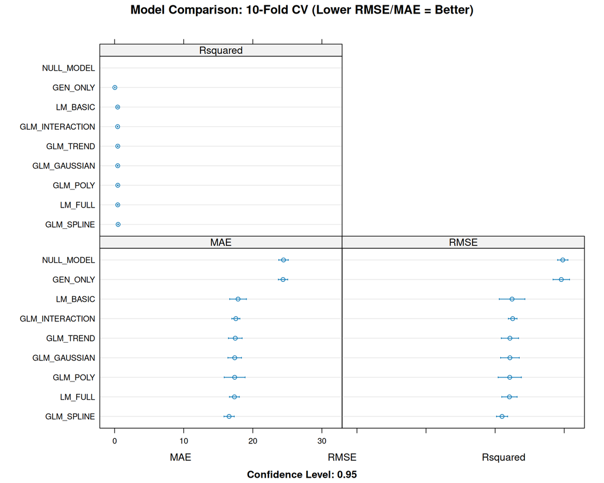

```r
# Create dotplot for visual comparison (from SAN_assignment_GLM_2.Rmd)
dotplot(model_list, main = "Model Comparison: 10-Fold CV (Lower RMSE/MAE = Better)")
```

## 8.3 Model Rankings

```r
# Create comparison table
cv_results <- summary(model_list)

cat("--- Model Rankings by RMSE ---\n")
```

```
## --- Model Rankings by RMSE ---
```

```r
rmse_means <- cv_results$statistics$RMSE[, "Mean"]
rmse_ranking <- sort(rmse_means)
print(round(rmse_ranking, 3))
```

```
##      GLM_SPLINE         LM_FULL        GLM_POLY    GLM_GAUSSIAN       GLM_TREND
##          21.004          22.075          22.118          22.142          22.144
##        LM_BASIC GLM_INTERACTION        GEN_ONLY      NULL_MODEL
##          22.451          22.542          29.578          29.791
```

```r
cat("\n--- Model Rankings by MAE ---\n")
```

```
##
## --- Model Rankings by MAE ---
```

```r
mae_means <- cv_results$statistics$MAE[, "Mean"]
mae_ranking <- sort(mae_means)
print(round(mae_ranking, 3))
```

```
##      GLM_SPLINE         LM_FULL        GLM_POLY    GLM_GAUSSIAN       GLM_TREND
##          16.570          17.337          17.372          17.380          17.460
## GLM_INTERACTION        LM_BASIC        GEN_ONLY      NULL_MODEL
##          17.545          17.863          24.374          24.445
```

```r
cat("\n--- Model Rankings by R² ---\n")
```

```
##
## --- Model Rankings by R² ---
```

```r
r2_means <- cv_results$statistics$Rsquared[, "Mean"]
r2_ranking <- sort(r2_means, decreasing = TRUE)
print(round(r2_ranking, 3))
```

```
##      GLM_SPLINE        GLM_POLY       GLM_TREND         LM_FULL    GLM_GAUSSIAN
##           0.505           0.456           0.452           0.449           0.447
##        LM_BASIC GLM_INTERACTION        GEN_ONLY
##           0.438           0.435           0.030
```

## 8.4 AIC Comparison

```r
cat("--- AIC Comparison of Final Models ---\n")
```

```
## --- AIC Comparison of Final Models ---
```

```r
final_models_aic <- data.frame(
  Model = c("NULL_MODEL", "GEN_ONLY", "LM_BASIC", "LM_FULL", "GLM_GAUSSIAN",
            "GLM_POLY", "GLM_SPLINE", "GLM_TREND", "GLM_INTERACTION"),
  AIC = c(
    AIC(m_null$finalModel),
    AIC(m_gen_only$finalModel),
    AIC(m_lm_basic$finalModel),
    AIC(m_lm_full$finalModel),
    AIC(m_glm_gaussian$finalModel),
    AIC(m_glm_poly$finalModel),
    AIC(m_glm_spline$finalModel),
    AIC(m_glm_trend$finalModel),
    AIC(m_glm_interaction$finalModel)
  )
)
final_models_aic <- final_models_aic %>% arrange(AIC)
print(final_models_aic)
```

```
##             Model      AIC
## 1      GLM_SPLINE 9139.780
## 2         LM_FULL 9241.563
## 3        GLM_POLY 9245.565
## 4    GLM_GAUSSIAN 9248.835
## 5       GLM_TREND 9253.449
## 6 GLM_INTERACTION 9266.082
## 7        LM_BASIC 9292.335
## 8        GEN_ONLY 9844.647
## 9      NULL_MODEL 9862.028
```

# 9. Likelihood Ratio Tests for Generation Effect

```r
# Full model with generation
full_model_lr <- glm(attack ~ gen + hp + defense + sp_attack + sp_defense + speed +
                    rarity + weight_kg, data = pokemon, family = gaussian)

# Reduced model without generation
reduced_model <- glm(attack ~ hp + defense + sp_attack + sp_defense + speed +
                       rarity + weight_kg, data = pokemon, family = gaussian)

# Likelihood ratio test
lr_test <- lrtest(reduced_model, full_model_lr)
cat("--- Likelihood Ratio Test: Is Generation Significant? ---\n")
```

```
## --- Likelihood Ratio Test: Is Generation Significant? ---
```

```r
print(lr_test)
```

```
## Likelihood ratio test
##
## Model 1: attack ~ hp + defense + sp_attack + sp_defense + speed + rarity +
##     weight_kg
## Model 2: attack ~ gen + hp + defense + sp_attack + sp_defense + speed +
##     rarity + weight_kg
##   #Df  LogLik Df  Chisq Pr(>Chisq)
## 1  11 -4612.2
## 2  19 -4601.8  8 20.813    0.00766 **
## ---
## Signif. codes:  0 '***' 0.001 '**' 0.01 '*' 0.05 '.' 0.1 ' ' 1
```

```r
if (lr_test$`Pr(>Chisq)`[2] < 0.05) {
  cat("\nConclusion: Generation IS a significant predictor of Attack (p < 0.05)\n")
} else {
  cat("\nConclusion: Generation is NOT a significant predictor after controlling for other variables\n")
}
```

```
##
## Conclusion: Generation IS a significant predictor of Attack (p < 0.05)
```

# 10. Non-Linear Effects with Splines and Polynomials

## 10.1 Polynomial Model

```r
model_poly <- lm(attack ~ poly(gen_numeric, 2) +
                   poly(hp, 2) + poly(defense, 2) +
                   poly(speed, 2) + rarity,
                 data = pokemon)
cat("--- Model with Polynomial Terms (degree 2) ---\n")
```

```
## --- Model with Polynomial Terms (degree 2) ---
```

```r
summary(model_poly)
```

```
##
## Call:
## lm(formula = attack ~ poly(gen_numeric, 2) + poly(hp, 2) + poly(defense,
##     2) + poly(speed, 2) + rarity, data = pokemon)
##
## Residuals:
##     Min      1Q  Median      3Q     Max
## -53.016 -15.021  -1.833  14.029  79.980
##
## Coefficients:
##                        Estimate Std. Error t value Pr(>|t|)
## (Intercept)             77.0146     0.7176 107.326  < 2e-16 ***
## poly(gen_numeric, 2)1   31.8902    22.0625   1.445 0.148641
## poly(gen_numeric, 2)2  -17.3420    22.1554  -0.783 0.433961
## poly(hp, 2)1           289.5185    24.6818  11.730  < 2e-16 ***
## poly(hp, 2)2          -173.1176    25.1332  -6.888 9.92e-12 ***
## poly(defense, 2)1      288.7750    25.0879  11.511  < 2e-16 ***
## poly(defense, 2)2      -90.8475    24.2589  -3.745 0.000191 ***
## poly(speed, 2)1        211.7614    23.9213   8.852  < 2e-16 ***
## poly(speed, 2)2        -30.0769    22.0086  -1.367 0.172055
## raritySubLegendary       5.9106     3.3790   1.749 0.080557 .
## rarityLegendary          7.7546     4.9884   1.555 0.120372
## rarityMythical           2.9789     5.0589   0.589 0.556101
## ---
## Signif. codes:  0 '***' 0.001 '**' 0.01 '*' 0.05 '.' 0.1 ' ' 1
##
## Residual standard error: 21.7 on 1012 degrees of freedom
## Multiple R-squared:  0.4761, Adjusted R-squared:  0.4704
## F-statistic: 83.62 on 11 and 1012 DF,  p-value: < 2.2e-16
```

## 10.2 Natural Spline Model

```r
model_spline <- lm(attack ~ ns(gen_numeric, df = 3) +
                     ns(hp, df = 3) + ns(defense, df = 3) +
                     ns(speed, df = 3) + rarity,
                   data = pokemon)
cat("--- Model with Natural Splines (df=3) ---\n")
```

```
## --- Model with Natural Splines (df=3) ---
```

```r
summary(model_spline)
```

```
##
## Call:
## lm(formula = attack ~ ns(gen_numeric, df = 3) + ns(hp, df = 3) +
##     ns(defense, df = 3) + ns(speed, df = 3) + rarity, data = pokemon)
##
## Residuals:
##    Min     1Q Median     3Q    Max
## -53.65 -15.09  -2.01  14.13  77.59
##
## Coefficients:
##                          Estimate Std. Error t value Pr(>|t|)
## (Intercept)               -12.793      8.863  -1.443 0.149217
## ns(gen_numeric, df = 3)1    5.606      3.113   1.801 0.072073 .
## ns(gen_numeric, df = 3)2    2.193      4.183   0.524 0.600212
## ns(gen_numeric, df = 3)3    1.950      2.037   0.957 0.338661
## ns(hp, df = 3)1            62.711      5.394  11.625  < 2e-16 ***
## ns(hp, df = 3)2            57.926     15.890   3.645 0.000281 ***
## ns(hp, df = 3)3             5.464     12.368   0.442 0.658719
## ns(defense, df = 3)1       41.999      4.541   9.249  < 2e-16 ***
## ns(defense, df = 3)2       79.882     13.914   5.741 1.24e-08 ***
## ns(defense, df = 3)3       42.469     10.795   3.934 8.93e-05 ***
## ns(speed, df = 3)1         20.530      3.838   5.350 1.09e-07 ***
## ns(speed, df = 3)2         59.495     11.465   5.189 2.55e-07 ***
## ns(speed, df = 3)3         42.678     12.020   3.551 0.000402 ***
## raritySubLegendary          5.531      3.388   1.633 0.102843
## rarityLegendary             8.159      5.085   1.604 0.108922
## rarityMythical              2.599      5.089   0.511 0.609682
## ---
## Signif. codes:  0 '***' 0.001 '**' 0.01 '*' 0.05 '.' 0.1 ' ' 1
##
## Residual standard error: 21.69 on 1008 degrees of freedom
## Multiple R-squared:  0.4786, Adjusted R-squared:  0.4708
## F-statistic: 61.68 on 15 and 1008 DF,  p-value: < 2.2e-16
```

## 10.3 Linear Baseline

```r
model_linear <- lm(attack ~ gen_numeric + hp + defense + speed + rarity,
                   data = pokemon)
```

## 10.4 Model Comparison

```r
cat("--- Comparison: Linear vs Polynomial vs Spline ---\n")
```

```
## --- Comparison: Linear vs Polynomial vs Spline ---
```

```r
cat("\nAIC comparison:\n")
```

```
##
## AIC comparison:
```

```r
cat("Linear model:     AIC =", round(AIC(model_linear), 2), "\n")
```

```
## Linear model:     AIC = 9305.24
```

```r
cat("Polynomial model: AIC =", round(AIC(model_poly), 2), "\n")
```

```
## Polynomial model: AIC = 9222
```

```r
cat("Spline model:     AIC =", round(AIC(model_spline), 2), "\n")
```

```
## Spline model:     AIC = 9225.17
```

```r
cat("\nBIC comparison:\n")
```

```
##
## BIC comparison:
```

```r
cat("Linear model:     BIC =", round(BIC(model_linear), 2), "\n")
```

```
## Linear model:     BIC = 9349.62
```

```r
cat("Polynomial model: BIC =", round(BIC(model_poly), 2), "\n")
```

```
## Polynomial model: BIC = 9286.11
```

```r
cat("Spline model:     BIC =", round(BIC(model_spline), 2), "\n")
```

```
## Spline model:     BIC = 9309
```

```r
# ANOVA comparison (nested models)
cat("\nANOVA: Linear vs Spline\n")
```

```
##
## ANOVA: Linear vs Spline
```

```r
anova(model_linear, model_spline)
```

```
## Analysis of Variance Table
##
## Model 1: attack ~ gen_numeric + hp + defense + speed + rarity
## Model 2: attack ~ ns(gen_numeric, df = 3) + ns(hp, df = 3) + ns(defense,
##     df = 3) + ns(speed, df = 3) + rarity
##   Res.Df    RSS Df Sum of Sq      F    Pr(>F)
## 1   1016 520823
## 2   1008 474182  8     46641 12.393 < 2.2e-16 ***
## ---
## Signif. codes:  0 '***' 0.001 '**' 0.01 '*' 0.05 '.' 0.1 ' ' 1
```

**Findings:** Polynomial and spline models have lower AIC than linear, suggesting non-linear relationships exist (especially for HP and Defense). However, the generation effect itself is approximately linear — the non-linearity comes from combat stats, not from generation.

## 10.5 Visualize Non-Linear Effects

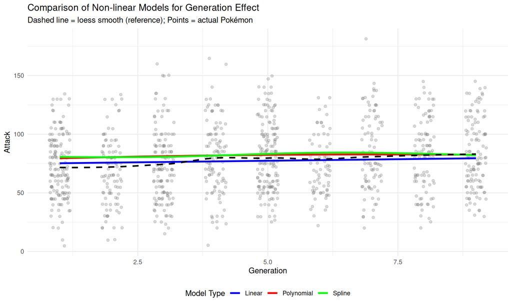

```r
# Create prediction data for visualization
gen_seq <- seq(1, 9, length.out = 100)
pred_data <- data.frame(
  gen_numeric = gen_seq,
  hp = mean(pokemon$hp),
  defense = mean(pokemon$defense),
  speed = mean(pokemon$speed),
  rarity = factor("Normal", levels = levels(pokemon$rarity))
)

pred_data$pred_linear <- predict(model_linear, newdata = pred_data)
pred_data$pred_poly <- predict(model_poly, newdata = pred_data)
pred_data$pred_spline <- predict(model_spline, newdata = pred_data)

# Plot comparison of linear vs polynomial vs spline
p_nonlinear <- ggplot() +
  geom_jitter(data = pokemon, aes(x = gen_numeric, y = attack),
              alpha = 0.3, width = 0.2, color = "gray50") +
  geom_line(data = pred_data, aes(x = gen_numeric, y = pred_linear, color = "Linear"),
            size = 1.2) +
  geom_line(data = pred_data, aes(x = gen_numeric, y = pred_poly, color = "Polynomial"),
            size = 1.2) +
  geom_line(data = pred_data, aes(x = gen_numeric, y = pred_spline, color = "Spline"),
            size = 1.2) +
  # Add loess smooth for reference (from glms.Rmd)
  geom_smooth(data = pokemon, aes(x = gen_numeric, y = attack),
              method = "loess", color = "black", linetype = "dashed",
              alpha = 0.3, se = FALSE) +
  scale_color_manual(values = c("Linear" = "blue", "Polynomial" = "red", "Spline" = "green")) +
  labs(title = "Comparison of Non-linear Models for Generation Effect",
       subtitle = "Dashed line = loess smooth (reference); Points = actual Pokémon",
       x = "Generation", y = "Attack", color = "Model Type") +
  theme_minimal() +
  theme(legend.position = "bottom")
print(p_nonlinear)
```